# Visualização de Dados

Visualização de Dados Luiz Fernando, Lyncoln, Ronaldo 03 de Julho de 2019

## Pacotes Utilizados

```r
library(dplyr)
library(tidyr)
library(readr)
library(purrr)
library(magrittr)
library(sf)
library(scales)
library(GGally)
library(ggpubr)
library(ggplot2)
library(grid)
library(gridExtra)
```

## Bases de dados

```r
# Base de dados separada por UF - Unidade da Federação
base_uf <- read_csv("http://bit.ly/base_uf")

# Base de dados separada por GR - Grande Região, apenas
#  com o número de nascidos vivos por mês
base_gr <- read_csv("http://bit.ly/base_gr") %>%
  select(-X)

# Base de dados separada por GR - Grande Região, com
#  a idade da mãe na ocasião do parto, sexo do nascido
#  vivo e local de nasicmento
base_completa <- read_csv("http://bit.ly/base_completa") %>%
  mutate(domicilio = as.numeric(domicilio))

base_uf
```

```
## # A tibble: 405 x 14
##      ano Janeiro Fevereiro Março Abril  Maio Junho Julho Agosto Setembro
##    <dbl>   <dbl>     <dbl> <dbl> <dbl> <dbl> <dbl> <dbl>  <dbl>    <dbl>
##  1  2003    2142      1866  2385  2343  2323  2184  2199   2171     2231
##  2  2004    2177      2078  2190  2107  2250  2150  2139   2097     2096
##  3  2005    2059      2162  2477  2361  2371  2227  2153   2220     2173
##  4  2006    1999      1924  2275  2264  2376  2195  1921   1955     2196
##  5  2007    2331      2141  2417  2210  2232  2065  2108   2038     2001
##  6  2008    2024      1874  2295  2096  2144  2070  2071   2118     2132
##  7  2009    2222      2077  2379  2258  1961  1949  2048   2080     2137
##  8  2010    1910      1764  2195  1994  2227  2069  2177   2075     2099
##  9  2011    2098      2019  2351  2299  2117  1966  1919   2042     1942
## 10  2012    2121      2126  2258  2185  2218  2190  2157   2001     1993
## # … with 395 more rows, and 4 more variables: Outubro <dbl>,
## #   Novembro <dbl>, Dezembro <dbl>, UF <chr>
```

```r
base_gr
```

```
## # A tibble: 75 x 14
##      ano Janeiro Fevereiro Março Abril  Maio Junho Julho Agosto Setembro
##    <dbl>   <dbl>     <dbl> <dbl> <dbl> <dbl> <dbl> <dbl>  <dbl>    <dbl>
##  1  2003   21791     19117 22186 21145 21790 19849 20235  19327    19122
##  2  2004   21830     20017 21697 20831 21185 19644 19544  19160    18797
##  3  2005   22665     20481 24394 23387 24019 22298 21227  21211    20823
##  4  2006   22775     20320 23545 22877 23114 21817 21038  21033    21125
##  5  2007   24598     21796 24270 22574 22794 22076 22016  21863    21110
##  6  2008   22780     20983 23687 23686 23917 22507 22407  22353    22827
##  7  2009   24338     21459 24786 23492 22623 21858 21834  21961    22792
##  8  2010   23851     21462 24422 23234 22896 21640 21854  21582    22463
##  9  2011   23170     21133 24064 23696 24704 23275 22934  23293    22665
## 10  2012   24967     22716 24518 23803 24203 22663 22980  23294    22691
## # … with 65 more rows, and 4 more variables: Outubro <dbl>,
## #   Novembro <dbl>, Dezembro <dbl>, GR <chr>
```

```r
base_completa
```

```
## # A tibble: 64,800 x 7
##    grande_regiao idade_da_mae_na…   ano mes_do_nascimen… sexo  hospital
##    <chr>         <chr>            <dbl> <chr>            <chr>    <dbl>
##  1 Norte         Menos de 15 anos  2003 Janeiro          Home…       84
##  2 Norte         Menos de 15 anos  2003 Janeiro          Mulh…      113
##  3 Norte         Menos de 15 anos  2003 Fevereiro        Home…       90
##  4 Norte         Menos de 15 anos  2003 Fevereiro        Mulh…       90
##  5 Norte         Menos de 15 anos  2003 Março            Home…      124
##  6 Norte         Menos de 15 anos  2003 Março            Mulh…       96
##  7 Norte         Menos de 15 anos  2003 Abril            Home…       94
##  8 Norte         Menos de 15 anos  2003 Abril            Mulh…       91
##  9 Norte         Menos de 15 anos  2003 Maio             Home…      117
## 10 Norte         Menos de 15 anos  2003 Maio             Mulh…      104
## # … with 64,790 more rows, and 1 more variable: domicilio <dbl>
```

## Visualizações

### Figura 1

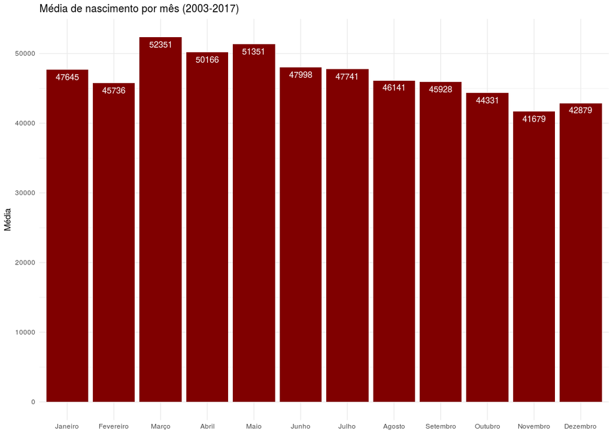

```r
meses_12 <- base_gr %>%
  bind_rows() %>%
  gather(mes, value, -ano, -GR) %>%
  distinct(mes)

base_gr %>%
  bind_rows() %>%
  gather(mes, value, -ano, -GR) %>%
  mutate(value = as.numeric(value)) %>%
  group_by(mes) %>%
  summarise(media = mean(value, na.rm = T)) %>%
  ungroup() %>%
  mutate(mes = factor(mes, levels = meses_12$mes)) %>%
  ggplot(aes(mes, media)) +
  geom_bar(stat = 'identity', fill = "#800000") +
  theme_minimal() +
  geom_text(aes(label = media %>% round),
            nudge_y = -1000,
            color = "white") +
  labs(x = "",
       y = "Média",
       title = "Média de nascimento por mês (2003-2017)")
```

Mediante ao gráfico de barras, pode-se concluir que a média de nascimentos para os anos de 2003 a 2017 nos meses de março a maio são maiores se comparado aos outros meses do ano. Diferente dos meses de novembro a dezembro que possuem a menor média de nascimentos. Assim, nove meses pós os meses do inverno são os que mais tiveram nascimentos no Brasil.

### Figura 2

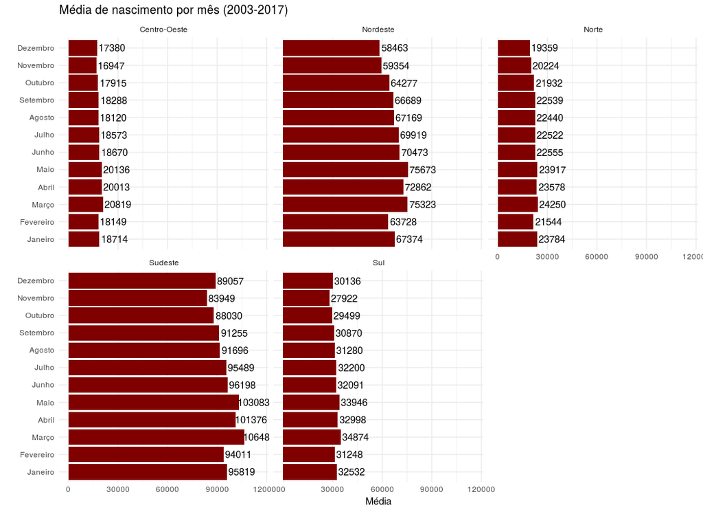

```r
base_gr %>%
  bind_rows() %>%
  gather(mes, value, -ano, -GR) %>%
  group_by(GR, mes) %>%
  summarise(media = mean(value, na.rm = T)) %>%
  ungroup() %>%
  mutate(mes = factor(mes, levels = meses_12$mes)) %>%
  ggplot(aes(mes, media)) +
  geom_bar(stat = 'identity', fill = "#800000") +
  facet_wrap(~ GR) +
  theme_minimal() +
  coord_flip() +
  geom_text(aes(label = media %>% round), nudge_y = 9000) +
  labs(x = "",
       y = "Média",
       title = "Média de nascimento por mês (2003-2017)")
```

A média do número de nascimentos na região Sudeste é bem maior das demais regiões do Brasil, um fator que é bem compreensível, dado que é a região onde se concentram mais de 40% da população do Brasil [(G1, 2018).](https://g1.globo.com/economia/noticia/2018/08/29/brasil-tem-mais-de-208-milhoes-de-habitantes-segundo-o-ibge.ghtml)

Decidimos então verificar se haveria alguma região em que estivesse afetando o fenômeno observado no gráfico anterior. Após a análise dos dados e a contrução do gráfico, concluímos que esse fenômeno (Maiores nascimentos nos meses de março a maio) acontece em todas as regiões do Brasil, exceto na região Norte, onde a média de nascimentos no mês de Janeiro é maior que a média de nascimentos no mês de Abril.

### Figura 3

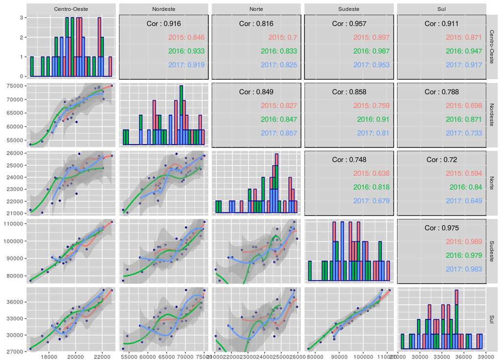

```r
base_gr %>%
  gather(meses, value, -ano, -GR) %>%
  spread(GR, value) %>%
  select(-meses) %>%
  tail(36) %>%
  mutate(ano = as.character(ano)) %>%
  ggpairs(
    columns = 2:6, mapping = aes(color = ano),
    lower = list(continuous = wrap(ggally_smooth_loess, size = 1, color = "darkblue")),
    diag = list(continuous = wrap(ggally_barDiag, color = "darkblue")),
    upper = list(continuous = wrap("cor", size = 4.0, alignPercent = 1))) +
  theme(panel.background = ggplot2::element_rect(fill = "lightgray"))
```

Para reforçarmos a ideia, decidimos utilizar de uma análise mais completa fazendo correlações do número de nascimentos nos últimos três anos entre as cinco regiões do Brasil. Podemos observar que analisando os anos mais recentes, todas as regiões estao fortemente correlacionadas entre elas.

As regiões Sul e Sudeste obtiveram a correlação mais forte (0.975), mostrando que há evidências de que o número de nascimentos entre estas 2 regiões se comporta de modo bem parecido. Por outro lado, temos que a menor correlação (0.72) foi entre as regiões Norte e Sul. Assim, pode-se afirmar que todos as variáveis se comportam de modo bem parecido.

### Figura 4

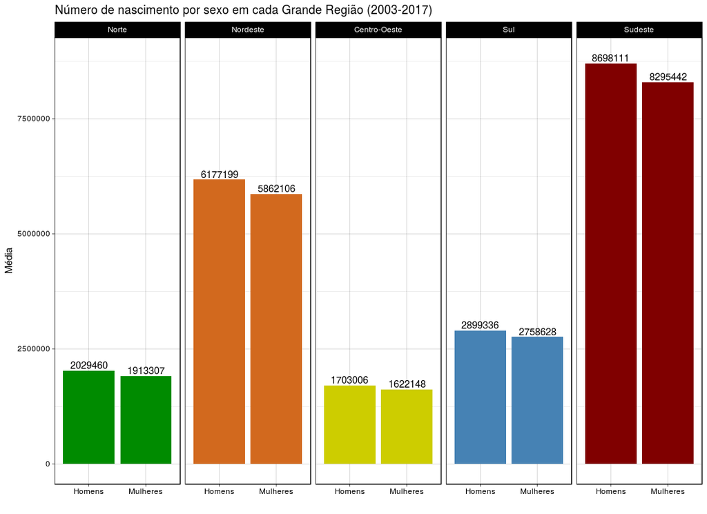

```r
base_completa %>%
  select(grande_regiao, sexo, hospital, domicilio) %>%
  group_by(grande_regiao, sexo) %>%
  summarise(hospital = sum(hospital, na.rm = T),
            domicilio = sum(domicilio, na.rm = T)) %>%
  ungroup() %>%
  mutate(total = hospital+domicilio,
         grande_regiao = factor(grande_regiao, levels = c("Norte", "Nordeste",
                                                          "Centro-Oeste", "Sul", "Sudeste"))) %>%
  select(-hospital, -domicilio) %>%
  ggplot(aes(x = sexo, y = total, fill = grande_regiao)) +
  facet_grid(~ grande_regiao) +
  scale_fill_manual(values = c("green4", "chocolate", "yellow3", "steelblue", "#800000")) +
  theme_linedraw() +
  theme(legend.position = "none") +
  geom_bar(stat = 'identity') +
  geom_text(aes(label = total), nudge_y = 120000) +
  labs(x = "",
       y = "Média",
       title = "Número de nascimento por sexo em cada Grande Região (2003-2017)")
```

Um outro fator relevante para ser analisado foi a questão do número de nascimentos por sexo, tanto em hospitais quanto em domicílios. No gráfico acima podemos verificar que em todas as regiões do brasil o número de nascimentos de homens é maior ao de mulheres. Essa diferença é maior ainda quando olhamos apenas para a região sudeste, onde o valor dessa diferença chega a mais de 400 mil nascimentos.

### Figura 5

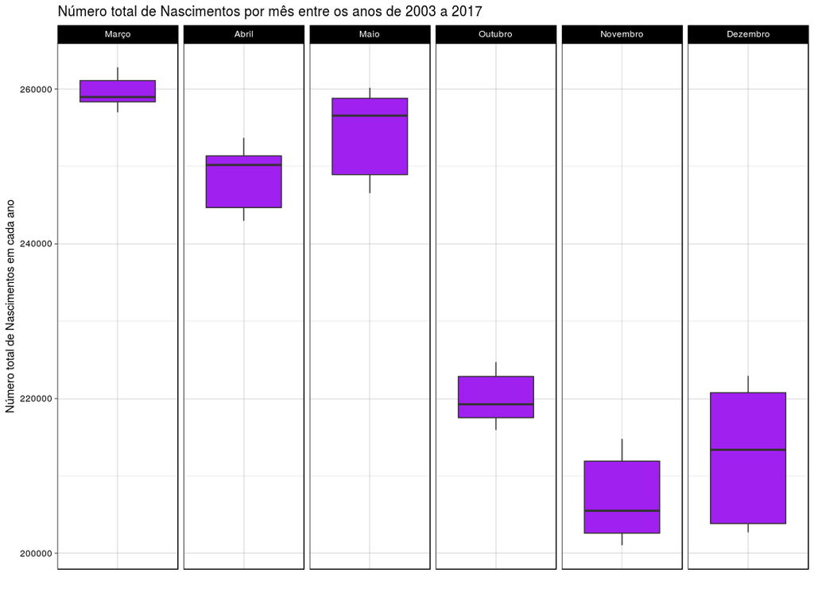

```r
base_completa %>%
  select(mes_do_nascimento, ano, hospital, domicilio) %>%
  filter(mes_do_nascimento %in% c("Março", "Abril", "Maio",
                                  "Outubro", "Novembro", "Dezembro")) %>%
  group_by(ano, mes_do_nascimento) %>%
  summarise(hospital = sum(hospital, na.rm = T),
            domicilio = sum(domicilio, na.rm = T)) %>%
  ungroup() %>%
  mutate(total = hospital+domicilio,
         ano = as.character(ano),
         mes_do_nascimento = factor(mes_do_nascimento, levels = c("Março", "Abril", "Maio",
                                                                  "Outubro", "Novembro", "Dezembro"))) %>%
  ggplot() +
  facet_grid(~ mes_do_nascimento, scales = "free_x") +
  geom_boxplot(aes(x = mes_do_nascimento, y = total), fill = "purple") +
  theme_linedraw() +
  theme(axis.text.x.bottom = element_blank(), axis.ticks.x.bottom = element_blank()) +
  labs(x = "",
       y = "Número total de Nascimentos em cada ano",
       title = "Número total de Nascimentos por mês entre os anos de 2003 a 2017")
```

Tentando entender melhor o comportamento da nossa variável, construimos boxplots para o número total de nascimentos dos meses em que têm mais (Março, Abril, Maio) e menos (Outubro,Novembro, Dezembro) nascimentos nos anos de 2003 até 2017. A diferença de nascimentos das duas trincas é bem maior quando analisamos elas separadamente.

### Figura 6

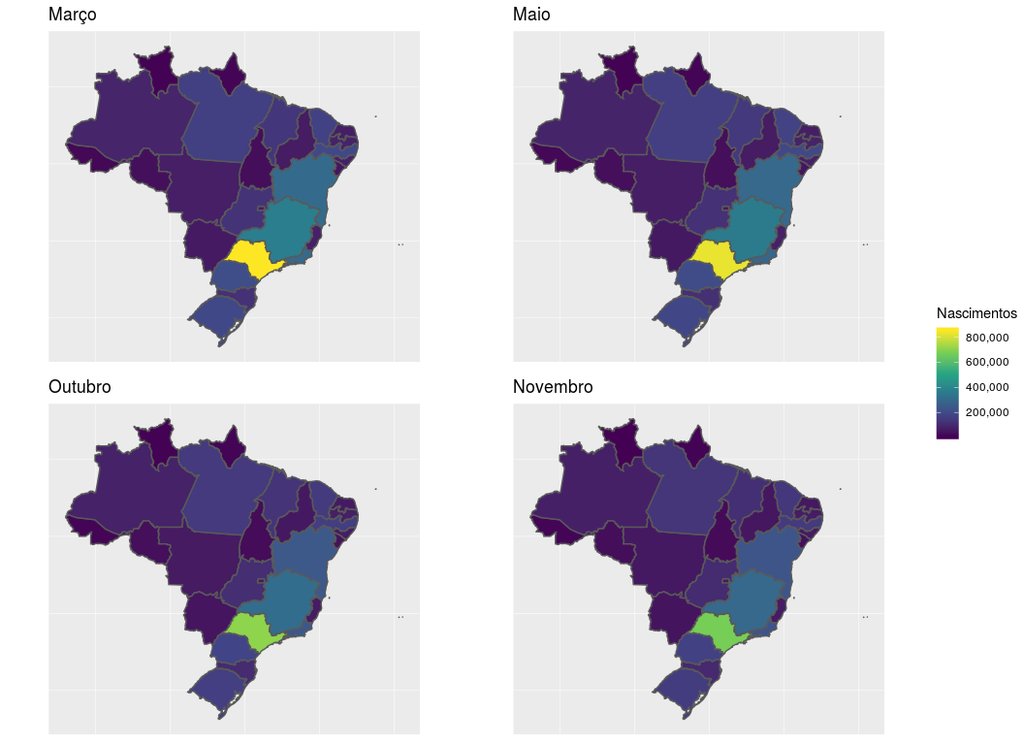

```r
bd = base_uf

mapa = sf::st_read("malha/BRUFE250GC_SIR.shp")
bd = bd %>% group_by(UF) %>% select(-ano) %>% summarise_all(sum)

bd %<>% mutate(UF = toupper(UF))

mapa = mapa %>% inner_join(bd, by= c("NM_ESTADO"="UF"))

mapaMar = ggplot(mapa) +
  geom_sf(aes(fill = `Março`)) +
  scale_fill_continuous(name = "Nascimentos",
                        type = "viridis",
                        limits = c(min(bd[2:13]),max(bd[2:13])),
                        labels = comma)+
  ggtitle("Março") +
  theme(axis.title.x=element_blank(),
        axis.text.x=element_blank(),
        axis.ticks.x=element_blank(),
        axis.title.y=element_blank(),
        axis.text.y=element_blank(),
        axis.ticks.y=element_blank()
  )

mapaMai = ggplot(mapa) +
  geom_sf(aes(fill = `Maio`)) +
  scale_fill_continuous(type = "viridis",
                        limits = c(min(bd[2:13]),max(bd[2:13])),
                        labels = comma) +
  ggtitle("Maio") +
  theme(axis.title.x=element_blank(),
        axis.text.x=element_blank(),
        axis.ticks.x=element_blank(),
        axis.title.y=element_blank(),
        axis.text.y=element_blank(),
        axis.ticks.y=element_blank())

mapaNov = ggplot(mapa) +
  geom_sf(aes(fill = `Novembro`)) +
  scale_fill_continuous(type = "viridis",
                        limits = c(min(bd[2:13]), max(bd[2:13])),
                        labels = comma) +
  ggtitle("Novembro") +
  theme(axis.title.x=element_blank(),
        axis.text.x=element_blank(),
        axis.ticks.x=element_blank(),
        axis.title.y=element_blank(),
        axis.text.y=element_blank(),
        axis.ticks.y=element_blank())

mapaOut = ggplot(mapa) +
  geom_sf(aes(fill = `Outubro`)) +
  scale_fill_continuous(type = "viridis",
                        limits = c(min(bd[2:13]), max(bd[2:13])),
                        labels = comma) +
  ggtitle("Outubro") +
  theme(axis.title.x=element_blank(),
        axis.text.x=element_blank(),
        axis.ticks.x=element_blank(),
        axis.title.y=element_blank(),
        axis.text.y=element_blank(),
        axis.ticks.y=element_blank())

ggarrange(
  mapaMar,
  mapaMai,
  mapaOut,
  mapaNov,
  ncol = 2,
  nrow = 2,
  common.legend = TRUE,
  legend = "right"
)
```

Selecionamos 2 dos meses com maior número médio de nascimentos (Março e Maio) e 2 dos meses com menor número médio de nascimentos (Outubro e Novembro) para verificar o número de nascimentos em cada estado do Brasil. Realizamos a soma dos valores de nascimento dos anos de 2003 a 2017 para os meses selecionados e com a visualização pode-se perceber que São Paulo possui o maior número total de nascimentos e aparenta ser o causador do número de nascimento em março e maio ser tão grande.

### Figura 7

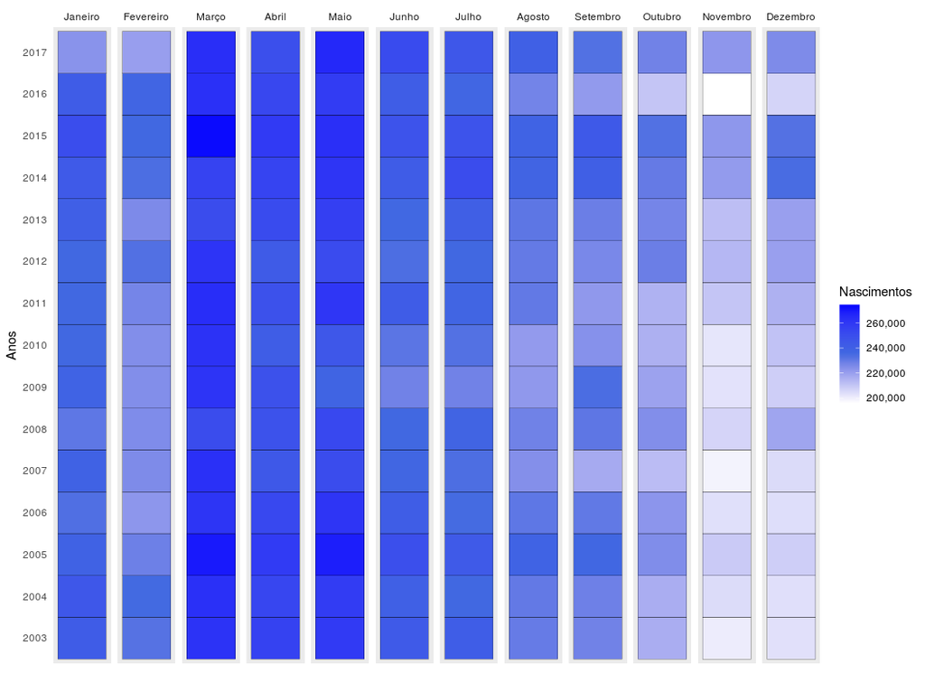

```r
bd = base_uf

bd %<>% select(-UF) %>% group_by(ano) %>% summarise_all(sum)

bd = bd %>% gather(meses, valores,-ano)

bd$meses = factor(bd$meses,levels = meses_12$mes)
bd$ano = factor(bd$ano)

ggplot(bd,aes(x = meses, y = ano))+
  geom_tile(aes(fill = valores), col = "black") +
  scale_fill_gradient2(
    low = "white",
    mid = "royalblue",
    high = "blue",
    midpoint = mean(pull(bd[, 3])),
    name = "Nascimentos",
    limits = c(min(bd[, 3]), max(bd[, 3])),
    labels = comma
  ) +
  facet_grid(~ meses,scales = "free") +
  labs(x = "Meses", y = "Anos") +
  theme(
    panel.grid = element_blank(),
    panel.border = element_blank(),
    axis.ticks = element_blank(),
    strip.background = element_blank(),
    axis.title.x = element_blank(),
    axis.text.x = element_blank(),
    axis.ticks.x = element_blank()
  )
```

#### RPUBS

O trabalho se encontra disponível no [RPubs.](http://www.rpubs.com/luizfcp/trab_final_visualizacao)